# Project 2

```
## [1] "ADDRESSES"    "AFFILIATIONS" "MANDATES"     "PERSONS"
```

# Part 1

Number of people with an active mandate changed over the years

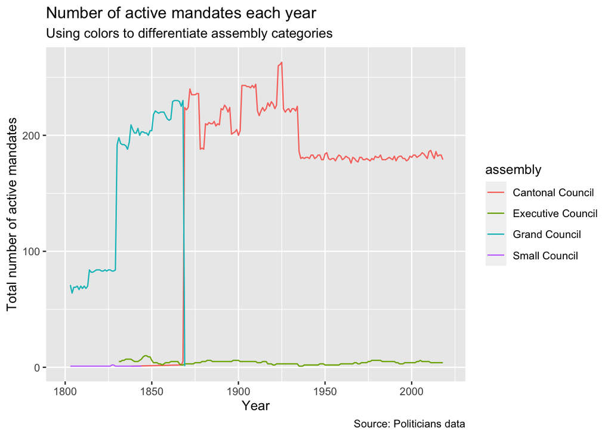

```r
MD_tbl_short <- mandates_tbl %>%
  select(-mandate_start_day,
         -mandate_start_month,
         -mandate_end_day,
         -mandate_end_month) %>%
  mutate (mandate_end_year = as.numeric(ifelse (mandate_start_year > 1900
                                   & mandate_end_year == "0", "2019",mandate_end_year )))

AF_tbl_short<-affiliations_tbl%>%
  select(-affiliation_start_day,-affiliation_start_month,
         -affiliation_end_day,-affiliation_end_month)

#mandate_affiliation_left_tbl<-left_join(MD_tbl_short,AF_tbl_short, by=c("id","person_id"))
mandate_affiliation_left_tbl<-left_join(MD_tbl_short,AF_tbl_short, by=c("id"))
#mandate_affiliation_left_tbl<-left_join(MD_tbl_short,AF_tbl_short, by=c("person_id"))

mandates_counted_years<-mandate_affiliation_left_tbl %>%
  filter(mandate_start_year>0,mandate_end_year>0) %>%
  mutate(active_year=map2(mandate_start_year,mandate_end_year-1,seq)) %>%
  group_by(assembly) %>%
  unnest_longer(col = active_year) %>%
  count(active_year) %>%
  ungroup()

mandates_counted_years %>% drop_na() %>%
  ggplot(mapping=aes(x=active_year,
                     y=n)) + xlim(1800, 2020)+
  geom_line(aes(group=assembly, color=assembly)) +
  theme(legend.position="right", legend.box = "horizontal")+
  labs (title = "Number of active mandates each year",
        subtitle = "Using colors to differentiate assembly categories",
        caption = "Source: Politicians data",
        x = "Year",
        y = "Total number of active mandates")
```

# Part 2

Facet charts with one chart per assembly seperated for men and women

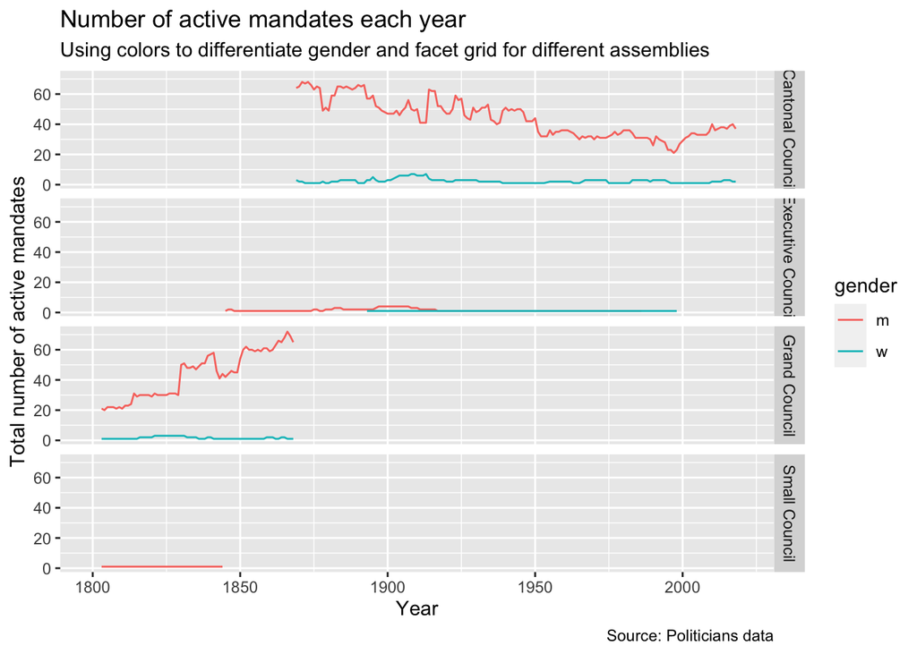

```r
mandates_counted_years_assembly_gender<-mandate_affiliation_left_tbl %>%
  left_join(persons_tbl, by=c("id"))%>%
  filter(mandate_start_year>0,mandate_end_year>0, !is.na(gender)) %>%
  mutate(active_year=map2(mandate_start_year,mandate_end_year-1,seq)) %>%
  group_by(gender,assembly) %>%
  unnest_longer(col = active_year) %>%
  count(active_year) %>%
  ungroup(assembly)

mandates_counted_years_assembly_gender %>%
  ggplot(mapping=aes(x=active_year,
                     y=n)) + xlim(1800, 2020)+
   scale_size(range = c(8, 12))+
  geom_line(aes(group=gender, color=gender)) +
  facet_grid(vars(assembly)) +
  theme(legend.position="right", legend.box = "horizontal")+
  labs (title = "Number of active mandates each year",
        subtitle = "Using colors to differentiate gender and facet grid for different assemblies",
        caption = "Source: Politicians data",
        x = "Year",
        y = "Total number of active mandates")
```

# Part 3

Proportion of elected politicians from each party in year 2000

```r
Elected_politician_2000<- mandate_affiliation_left_tbl%>%
  filter(affiliation_start_year>0,affiliation_end_year>0, affiliation_end_year<2020) %>%
  select(id,assembly,party,affiliation_start_year,affiliation_end_year)%>%
  mutate(affiliation_active_year=map2(affiliation_start_year,affiliation_end_year,seq)) %>%
  #group_by(party) %>%
  unnest_longer(col = affiliation_active_year) %>%
  group_by(affiliation_active_year,party) %>%
  ungroup(party) %>%
  filter(affiliation_start_year==2000)


Proportion_Elected_politician_2000<-Elected_politician_2000%>%
  group_by(assembly,party)%>%
  summarise(n=n())%>%
  mutate(proportion=n/sum(n))%>%
  ungroup(party)

Proportion_Elected_politician_2000 %>%
  knitr::kable(caption = "proportion of elected politicians from each party in year 2000") %>%
  kableExtra::kable_styling(
    bootstrap_options = "striped",
    full_width = F,
    position = "left"
  )
```

proportion of elected politicians from each party in year 2000

| assembly | party | n | proportion |
| --- | --- | --- | --- |
| Cantonal Council | EVP | 8 | 0.2352941 |
| Cantonal Council | FDP | 16 | 0.4705882 |
| Cantonal Council | LdU | 2 | 0.0588235 |
| Cantonal Council | SP | 8 | 0.2352941 |

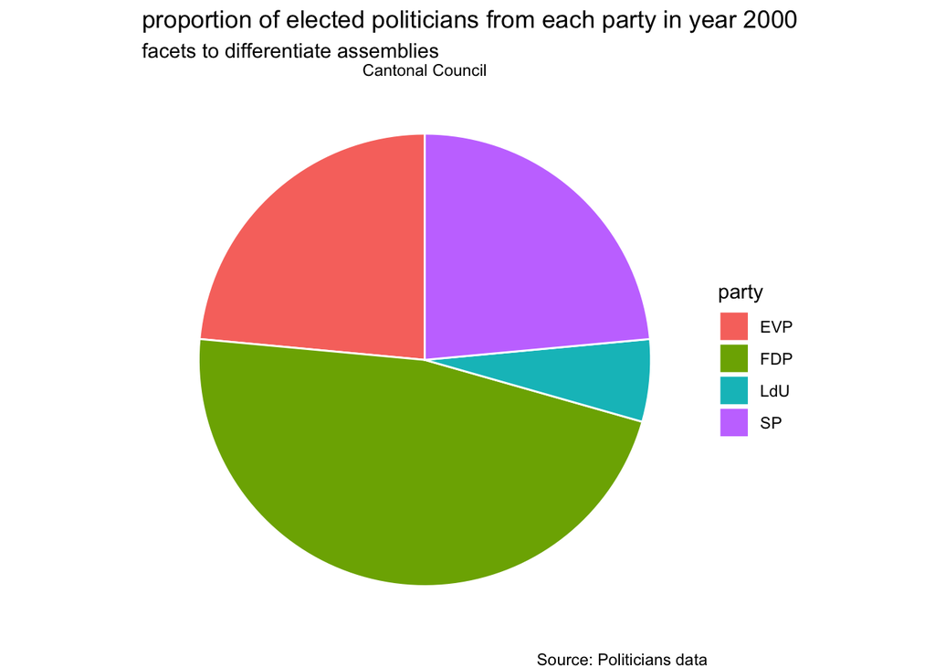

```r
ggplot(Proportion_Elected_politician_2000, aes(x="", y=proportion, fill=party)) +
  geom_bar(stat="identity", width=1, color="white") +
  coord_polar("y", start=0) +  facet_grid(facets=. ~ assembly)+
  theme_void() +
  labs (title = "proportion of elected politicians from each party in year 2000 ",
        subtitle = "facets to differentiate assemblies",
        caption = "Source: Politicians data")
```

# Part 4

Change in the composition of assemblies over the years

[figure not shown]

```r
Composition_assembly_party_by_year<- mandate_affiliation_left_tbl%>%
  filter(affiliation_start_year>0,affiliation_end_year>0 & affiliation_end_year<2020) %>%
  select(id,assembly,party,affiliation_start_year,affiliation_end_year)%>%
  mutate(affiliation_active_year=map2(affiliation_start_year,affiliation_end_year,seq)) %>%
  unnest_longer(col = affiliation_active_year) %>%
  group_by(assembly,affiliation_active_year, party) %>%
  summarise(n=n())%>%
  mutate(proportion=n/sum(n))%>%
  ungroup(affiliation_active_year, party)

Composition_assembly_party_by_year %>%
  ggplot(mapping=aes(x=affiliation_active_year,
                     y=proportion)) + xlim(1980, 2020)+
  geom_line(aes(group=party, color=party)) +
  facet_grid(vars(assembly)) +
  theme(legend.position="right")+
  labs (title = "composition of assemblies across year",
        subtitle = "Using colors to differentiate party and facet grid for assemblies",
        caption = "Source: Politicians data",
        x = "Year",
        y = "Proportion of parties in an assembly")
```

```r
# Problem in placing legend box on right. The whole screen is covered by the legend box
```

# Part 5

Polticians with year of death in the data

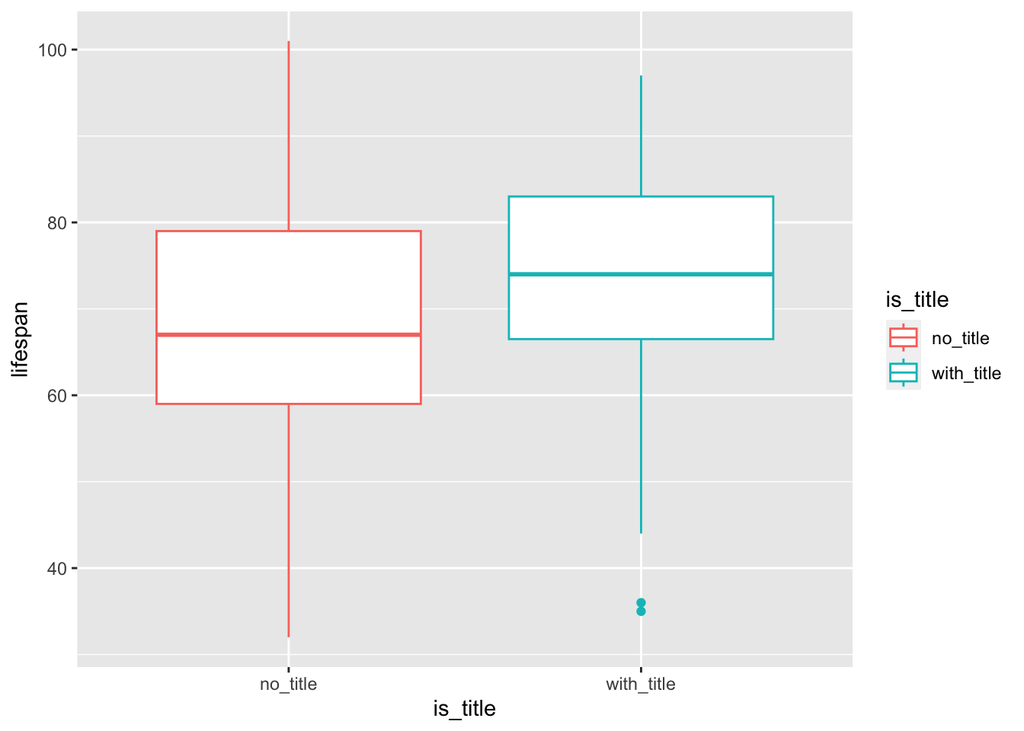

```r
Politicians_death<-persons_tbl%>%
  arrange(desc(year_of_death))%>%
  filter(year_of_death>=0,year_of_birth!=0) %>%
  mutate(lifespan=as.numeric(year_of_death)-as.numeric(year_of_birth)) %>%
  filter(lifespan>5 & lifespan<120)

Average_politicians_age<-Politicians_death%>%
  select(title, lifespan)%>%
  mutate(title = na_if(title, ""))%>%
  mutate(is_title=ifelse(is.na(title),"no_title","with_title"))%>%
  group_by(is_title)%>%
  summarise(average_lifespan=mean(lifespan))%>%
  ungroup()

Politicians_death_table <- Politicians_death %>%
  select(title, lifespan)%>%
  mutate(title = na_if(title, ""))%>%
  mutate(is_title=ifelse(is.na(title),"no_title","with_title")) %>%
  select(is_title, lifespan)

Politicians_death_table %>%
  ggplot2::ggplot(mapping = aes( y = lifespan, x=is_title,group=is_title)) +
  geom_boxplot(aes(colour=is_title))
```

```r
Politicians_death_table %>%
  select(is_title,lifespan) %>%
  infer::t_test( lifespan ~ is_title,
                 order = c("no_title","with_title"),
                 var.equal = FALSE)
```

```
## # A tibble: 1 × 7
##   statistic  t_df    p_value alternative estimate lower_ci upper_ci
##       <dbl> <dbl>      <dbl> <chr>          <dbl>    <dbl>    <dbl>
## 1     -4.93  417. 0.00000116 two.sided      -5.52    -7.71    -3.32
```

Using the box plot, it looks **lifepsan** is higher for politicians with **with_title** than **no_title**.

After doing t-test on variable lifespan for for politicians with **with_title** than **no_title**, it can be observed that two groups are not comparable (or not similar) for the variable **is_title**. This conclusion was deduced by looking at the box plot and also checking the p-value from the t-test which is less than 0.05.

# Part 6

Polticians born before and after 1918

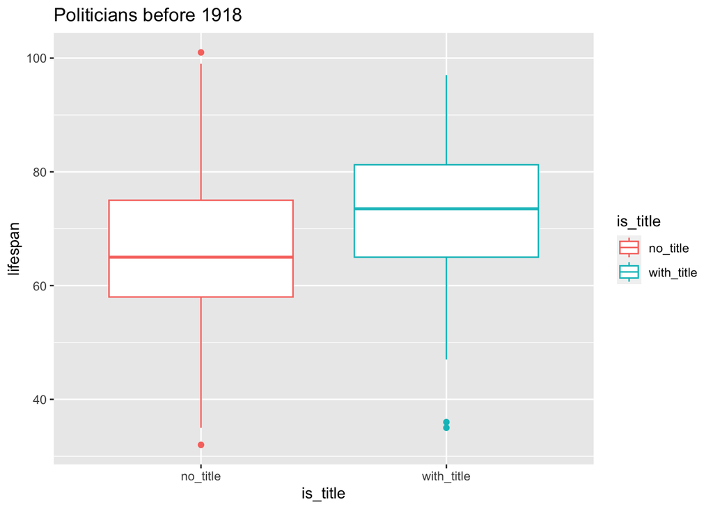

```r
Politicians_born_1918_title<-Politicians_death%>%
  arrange(desc(year_of_birth))%>%
  filter(year_of_birth!=0) %>%
  select(id, year_of_birth, title, lifespan) %>%
  mutate(title = na_if(title, ""))%>%
  mutate(is_title=ifelse(is.na(title),"no_title","with_title")) %>%
  mutate(is_born=ifelse(year_of_birth<1918,"before_1918","after_1918"))%>%
  select(id, is_title, is_born, lifespan)

Politician_1918_avg_lifespan<-Politicians_born_1918_title %>%
  group_by(is_born,is_title)%>%
  summarise(average_lifespan=mean(lifespan))

# Filter data sets to make two data sets for t-test

Politician_before_1918<-Politicians_born_1918_title %>%
  filter(is_born=="before_1918")

Politician_before_1918 %>%
  ggplot2::ggplot(mapping = aes( x=is_title,y = lifespan, group=is_title)) +
  geom_boxplot(aes(colour=is_title)) +
  labs(title = "Politicians before 1918")
```

```r
Politician_before_1918 %>% select(is_title,lifespan) %>%
  infer::t_test( lifespan ~ is_title,
                 order = c("no_title","with_title"),
                 var.equal = TRUE)
```

```
## # A tibble: 1 × 7
##   statistic  t_df    p_value alternative estimate lower_ci upper_ci
##       <dbl> <dbl>      <dbl> <chr>          <dbl>    <dbl>    <dbl>
## 1     -4.69   466 0.00000355 two.sided      -5.75    -8.16    -3.34
```

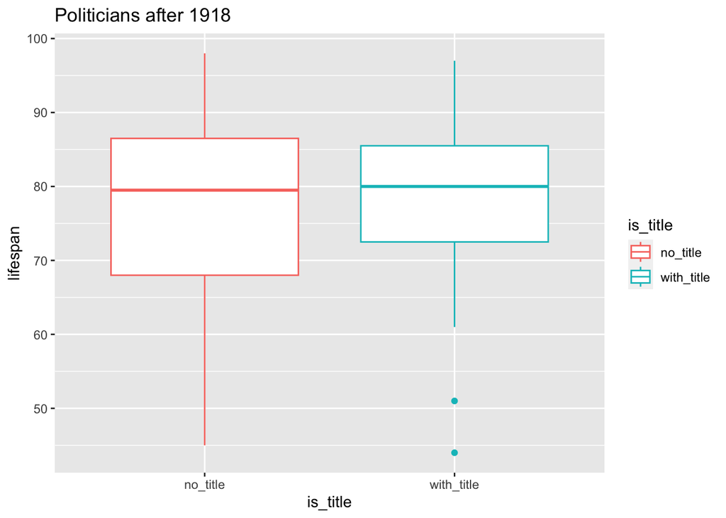

```r
Politician_after_1918<-Politician_before_1918<-Politicians_born_1918_title %>%
  filter(is_born=="after_1918")
Politician_after_1918 %>%
  ggplot2::ggplot(mapping = aes( x=is_title,y = lifespan, group=is_title)) +
  geom_boxplot(aes(colour=is_title))+
  labs(title = "Politicians after 1918")
```

```r
Politician_after_1918 %>% select(is_title,lifespan) %>%
  infer::t_test( lifespan ~ is_title,
                 order = c("no_title","with_title"),
                 var.equal = TRUE)
```

```
## # A tibble: 1 × 7
##   statistic  t_df p_value alternative estimate lower_ci upper_ci
##       <dbl> <dbl>   <dbl> <chr>          <dbl>    <dbl>    <dbl>
## 1    -0.236    81   0.814 two.sided     -0.611    -5.76     4.54
```

There is difference in lifespan for politicians borne before 1918 with and without title.

p-value looks quite significant for comparison of average lifespan for politician born before 1918 with and wihout title.

p-value does not look significant for comparison of average lifespan for politician born after 1918 with and wihout title.

# Part 7

Most number of mandates by a politician

```r
politician_name<-persons_tbl %>%
  select(id, firstname, lastname) %>%
  mutate(fullname=str_c(firstname, lastname, sep=" "))

number_mandates_by_politician<- mandate_affiliation_left_tbl%>%
  full_join(politician_name, by=c("id")) %>%
  drop_na() %>%
  select(person_id.x,mandate_id,fullname) %>%
  group_by(person_id.x)%>%
  mutate(number_mandates=n())%>%
  ungroup(person_id.x)%>%
  top_n(10)

number_mandates_by_politician %>%
    knitr::kable(caption = "Most number of mandates by a politician") %>%
    kableExtra::kable_styling(
      bootstrap_options = "striped",
      full_width = F,
      position = "left"
    )
```

Most number of mandates by a politician

| person_id.x | mandate_id | fullname | number_mandates |
| --- | --- | --- | --- |
| 11772 | 3224 | Hans Widmer | 5 |
| 11772 | 3225 | Walter Roth | 5 |
| 11772 | 3226 | Jakob Kessler | 5 |
| 11772 | 3229 | Eduard Leimbacher | 5 |
| 11772 | 3228 | Emil Frei | 5 |
| 15011 | 5146 | Erich Schmid | 6 |
| 15011 | 5147 | Armin Schück | 6 |
| 15011 | 5148 | Max Dünki | 6 |
| 15011 | 5149 | Ernst Spillmann | 6 |
| 15011 | 5150 | Theodor Wildbolz | 6 |
| 15011 | 5151 | Martin Schlappner | 6 |

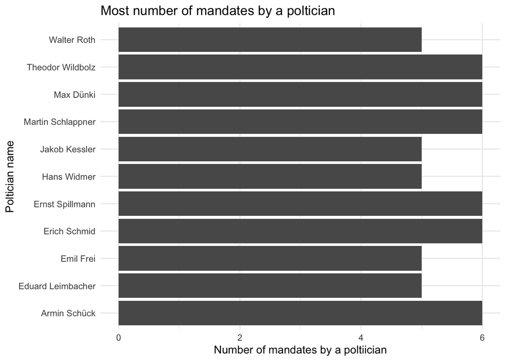

```r
number_mandates_by_politician %>%
  ggplot(aes(y=as.character(fullname), x=number_mandates))+
  geom_bar(stat="identity")+ theme_minimal() +
  labs (title = "Most number of mandates by a poltician",
    x = "Number of mandates by a poltiician",
    y = "Poltician name")
```

# Part 8

Politicians associated with multiple mandates at the same time

```r
politicians_multiple_mandates<-mandate_affiliation_left_tbl %>%
  filter(mandate_start_year>0,mandate_end_year>0) %>%
  mutate(active_year=map2(mandate_start_year,mandate_end_year,seq)) %>%
  group_by(person_id.x) %>%
  unnest_longer(col = active_year) %>%
  #mutate(number_of_mandates=n()) %>%
  count(active_year)%>%
  ungroup()

count_politicians_multiple_mandates<-politicians_multiple_mandates %>%
  group_by(n,active_year) %>%
  #mutate(total_number_politician_with_n_number_of_mandates=count("number_of_mandates")) %>%
  count("politician with n number of mandates") %>%
  filter(n>1) %>%
  ungroup(active_year)

count_politicians_multiple_mandates %>%
    knitr::kable(caption = "Politician with n number of mandates") %>%
    kableExtra::kable_styling(
      bootstrap_options = "striped",
      full_width = F,
      position = "left"
    )
```

Politician with n number of mandates

| n | active_year | “politician with n number of mandates” | nn |
| --- | --- | --- | --- |
| 2 | 1803 | politician with n number of mandates | 1 |
| 2 | 1804 | politician with n number of mandates | 1 |
| 2 | 1805 | politician with n number of mandates | 1 |
| 2 | 1806 | politician with n number of mandates | 1 |
| 2 | 1807 | politician with n number of mandates | 1 |
| 2 | 1808 | politician with n number of mandates | 1 |
| 2 | 1809 | politician with n number of mandates | 1 |
| 2 | 1810 | politician with n number of mandates | 1 |
| 2 | 1811 | politician with n number of mandates | 2 |
| 2 | 1812 | politician with n number of mandates | 1 |
| 2 | 1813 | politician with n number of mandates | 1 |
| 2 | 1814 | politician with n number of mandates | 1 |
| 2 | 1815 | politician with n number of mandates | 1 |
| 2 | 1816 | politician with n number of mandates | 1 |
| 2 | 1817 | politician with n number of mandates | 1 |
| 2 | 1818 | politician with n number of mandates | 1 |
| 2 | 1819 | politician with n number of mandates | 1 |
| 2 | 1820 | politician with n number of mandates | 1 |
| 2 | 1821 | politician with n number of mandates | 1 |
| 2 | 1822 | politician with n number of mandates | 1 |
| 2 | 1823 | politician with n number of mandates | 1 |
| 2 | 1824 | politician with n number of mandates | 1 |
| 2 | 1825 | politician with n number of mandates | 1 |
| 2 | 1826 | politician with n number of mandates | 1 |
| 2 | 1827 | politician with n number of mandates | 2 |
| 2 | 1828 | politician with n number of mandates | 2 |
| 2 | 1829 | politician with n number of mandates | 2 |
| 2 | 1830 | politician with n number of mandates | 7 |
| 2 | 1831 | politician with n number of mandates | 7 |
| 2 | 1832 | politician with n number of mandates | 27 |

[output cut: 104 more lines]

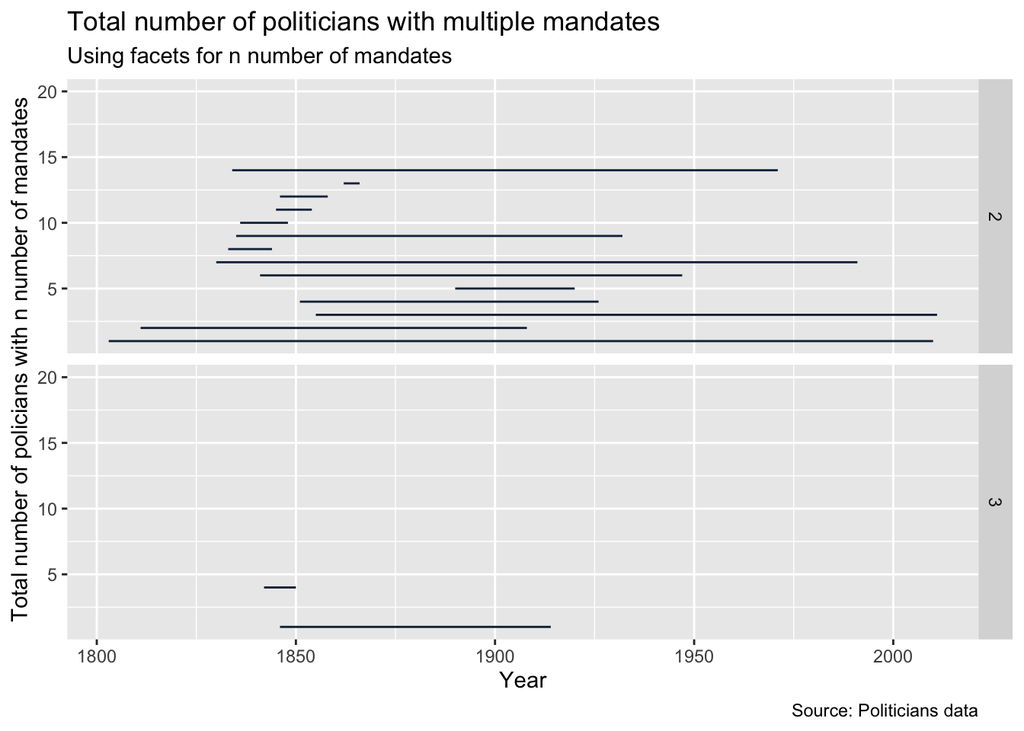

```r
count_politicians_multiple_mandates %>%
  ggplot(mapping=aes(x=active_year,
                     y=nn))+ ylim(1,20 ) +
  geom_line(aes(group=nn, color=nn)) +
  facet_grid(vars(n)) +
  theme(legend.position="none")+
  labs (title = "Total number of politicians with multiple mandates",
        subtitle = "Using facets for n number of mandates",
        caption = "Source: Politicians data",
        x = "Year",
        y = "Total number of policians with n number of mandates")
```

# Part 9

Politicians associated with different parties

```r
Policitian_party<-mandate_affiliation_left_tbl%>%
  select(id, person_id.x,party)%>%
  group_by(person_id.x)%>%
  mutate(number_of_party=n_distinct(party)) %>%
  arrange(desc(number_of_party)) %>%
  ungroup() %>%
  top_n(4)


Policitian_party_table<-Policitian_party %>%
  kable()
```

Politicians associated with different parties are:

| id | person_id.x | party | number_of_party |
| --- | --- | --- | --- |
| 2626 | 9468 | POCH | 6 |
| 2627 | 9468 | FDP | 6 |
| 2628 | 9468 | CVP | 6 |
| 2629 | 9468 | CVP | 6 |
| 2630 | 9468 | SVP | 6 |
| 2631 | 9468 | S | 6 |
| 2632 | 9468 | SP | 6 |

.

# Part 10

````r
# library(dplyr)
# library(purrr)
# library(magrittr)
#
# politician_address<-addresses_tbl%>%
#                   select(id, person_id,street, house_number, city, postal_code)%>%
#                   mutate_all(na_if,"") %>%
#                   dplyr::filter(complete.cases(.))
#
#
# politician_address_20<-politician_address %>%
#                     mutate(full_address=str_c(street, house_number, postal_code, city, sep=",")) %>%
#                     mutate(postal_code=as.numeric(str_extract(politician_address$postal_code, "\\d+"))) %>%
#                     mutate(house_number=as.numeric(str_extract(politician_address$house_number, "\\d+"))) %>%
#                     mutate(street=str_extract(politician_address$street, "\\w+")) %>%
#                     mutate(country="switzerland") %>%
#                     mutate_all(na_if,"") %>%
#                     dplyr::filter(complete.cases(.)) %>%
#                     mutate(address_geocode=str_glue_data(politician_address,"{street}","{house_number}","{postal_code}","{city}","{country}", .sep="+")) %>%
#                     top_n(30)
#
# slowGET <- function( url ) {
#   Sys.sleep(0.5)
#   print( url )
#   return ( GET(url) )
# }
#
# latitude_longitude <-str_glue("https://geocode.xyz/",
#                               "{politician_address_20$address_geocode}",
#                               "?json=1") %>%
#   map(GET) %>%
#   keep(~ status_code(.) == 200) %>%
#   map(content)
#
#
# latitude_longitude_extract<-latitude_longitude %>%
#  purrr::map_df(magrittr::extract, c("latt", "longt")) %>%
#  mutate(latt=as.numeric(latt),longt=as.numeric(longt))
#
# # I have commented the leaflet code below
#
# #library(leaflet)
# #latitude_longitude_extract %>%
# #leaflet() %>%
# #addTiles() %>%
# #addMarkers(lng=~longt,lat=~latt)
#
# library(ggmap)
# switzerland_area <- c(left=8.363203, bottom=47.298988, right=8.722582, top=47.456508)
# switzerland_map <- get_stamenmap(bbox=switzerland_area)
# ggmap(switzerland_map) +
#   geom_point(data=latitude_longitude_extract ,
#              aes(x=longt, y=latt, alpha=.5))+
#   labs(title="Where are policiticians in Switzerland?",
#        subtitle="Geolocation of 20 listings from the politician data in Switzerland")
# ```
````